# Which tree species should the city plant?

## 📖 Background

You work for a nonprofit organization advising the planning department on ways to improve the quantity and quality of trees in New York City. The urban design team believes tree size (using trunk diameter as a proxy for size) and health are the most desirable characteristics of city trees.

The city would like to learn more about which tree species are the best choice to plant on the streets of Manhattan.

## 💾 The data

The team has provided access to the 2015 tree census and geographical information on New York City neighborhoods ([trees](https://data.cityofnewyork.us/Environment/2015-Street-Tree-Census-Tree-Data/uvpi-gqnh), [neighborhoods](https://data.cityofnewyork.us/City-Government/NTA-map/d3qk-pfyz)):

#### Tree Census

- "tree_id" - Unique id of each tree.
- "tree_dbh" - The diameter of the tree in inches measured at 54 inches above the ground.
- "curb_loc" - Location of the tree bed in relation to the curb. Either along the curb (OnCurb) or offset from the curb (OffsetFromCurb).
- "spc_common" - Common name for the species.
- "status" - Indicates whether the tree is alive or standing dead.
- "health" - Indication of the tree's health (Good, Fair, and Poor).
- "root_stone" - Indicates the presence of a root problem caused by paving stones in the tree bed.
- "root_grate" - Indicates the presence of a root problem caused by metal grates in the tree bed.
- "root_other" - Indicates the presence of other root problems.
- "trunk_wire" - Indicates the presence of a trunk problem caused by wires or rope wrapped around the trunk.
- "trnk_light" - Indicates the presence of a trunk problem caused by lighting installed on the tree.
- "trnk_other" - Indicates the presence of other trunk problems.
- "brch_light" - Indicates the presence of a branch problem caused by lights or wires in the branches.
- "brch_shoe" - Indicates the presence of a branch problem caused by shoes in the branches.
- "brch_other" - Indicates the presence of other branch problems.
- "postcode" - Five-digit zip code where the tree is located.
- "nta" - Neighborhood Tabulation Area (NTA) code from the 2010 US Census for the tree.
- "nta_name" - Neighborhood name.
- "latitude" - Latitude of the tree, in decimal degrees.
- "longitude" - Longitude of the tree, in decimal degrees.

#### Neighborhoods' geographical information

- "ntacode" - NTA code (matches Tree Census information).
- "ntaname" - Neighborhood name (matches Tree Census information).
- "geometry" - Polygon that defines the neighborhood.

*Tree census and neighborhood information from the City of New York [NYC Open Data](https://opendata.cityofnewyork.us/data/).*

```python
#remove warnings
import warnings
warnings.filterwarnings('ignore')
#import modules
import pandas as pd
import geopandas as gpd
import numpy as np
import matplotlib.pyplot as plt
import seaborn as sns
import folium

#import trees data
trees = pd.read_csv('data/trees.csv')
trees = trees.rename(columns = {'trunk_wire' : 'trnk_wire'})
trees.head()
```

|  | tree_id | tree_dbh | curb_loc | spc_common | status | health | root_stone | root_grate | root_other | trnk_wire | trnk_light | trnk_other | brch_light | brch_shoe | brch_other | postcode | nta | nta_name | latitude | longitude |
| --- | --- | --- | --- | --- | --- | --- | --- | --- | --- | --- | --- | --- | --- | --- | --- | --- | --- | --- | --- | --- |
| 0 | 190422 | 11 | OnCurb | honeylocust | Alive | Good | No | No | No | No | No | No | No | No | No | 10023 | MN14 | Lincoln Square | 40.770046 | -73.984950 |
| 1 | 190426 | 11 | OnCurb | honeylocust | Alive | Good | No | No | No | No | No | No | No | No | No | 10023 | MN14 | Lincoln Square | 40.770210 | -73.985338 |
| 2 | 208649 | 9 | OnCurb | American linden | Alive | Good | No | Yes | No | No | No | No | No | No | No | 10019 | MN15 | Clinton | 40.762724 | -73.987297 |
| 3 | 193310 | 14 | OnCurb | honeylocust | Alive | Good | No | No | Yes | No | No | Yes | No | No | Yes | 10021 | MN40 | Upper East Side-Carnegie Hill | 40.772171 | -73.960456 |
| 4 | 199760 | 4 | OnCurb | willow oak | Alive | Fair | No | No | No | No | No | No | No | No | No | 10024 | MN12 | Upper West Side | 40.782087 | -73.980964 |

```python
def to_name(entry):
    words = entry.str.split()
    new_entry = ''
    for word in words:
        new_entry = ' '.join([new_entry, word])
        new_entry = new_entry.strip()
    return new_entry
```

```python
trees.head()
```

|  | tree_id | tree_dbh | curb_loc | spc_common | status | health | root_stone | root_grate | root_other | trnk_wire | trnk_light | trnk_other | brch_light | brch_shoe | brch_other | postcode | nta | nta_name | latitude | longitude |
| --- | --- | --- | --- | --- | --- | --- | --- | --- | --- | --- | --- | --- | --- | --- | --- | --- | --- | --- | --- | --- |
| 0 | 190422 | 11 | OnCurb | honeylocust | Alive | Good | No | No | No | No | No | No | No | No | No | 10023 | MN14 | Lincoln Square | 40.770046 | -73.984950 |
| 1 | 190426 | 11 | OnCurb | honeylocust | Alive | Good | No | No | No | No | No | No | No | No | No | 10023 | MN14 | Lincoln Square | 40.770210 | -73.985338 |
| 2 | 208649 | 9 | OnCurb | American linden | Alive | Good | No | Yes | No | No | No | No | No | No | No | 10019 | MN15 | Clinton | 40.762724 | -73.987297 |
| 3 | 193310 | 14 | OnCurb | honeylocust | Alive | Good | No | No | Yes | No | No | Yes | No | No | Yes | 10021 | MN40 | Upper East Side-Carnegie Hill | 40.772171 | -73.960456 |
| 4 | 199760 | 4 | OnCurb | willow oak | Alive | Fair | No | No | No | No | No | No | No | No | No | 10024 | MN12 | Upper West Side | 40.782087 | -73.980964 |

```python
#import neighborhoods geodata
neighborhoods = gpd.read_file('data/nta.shp')
neighborhoods.head()
```

|  | borocode | boroname | countyfips | ntacode | ntaname | shape_area | shape_leng | geometry |
| --- | --- | --- | --- | --- | --- | --- | --- | --- |
| 0 | 3.0 | Brooklyn | 047 | BK43 | Midwood | 3.579964e+07 | 27996.591274 | POLYGON ((-73.94733 40.62917, -73.94687 40.626... |
| 1 | 3.0 | Brooklyn | 047 | BK75 | Bedford | 3.262983e+07 | 29992.919174 | POLYGON ((-73.94193 40.70073, -73.94439 40.700... |
| 2 | 2.0 | Bronx | 005 | BX40 | Fordham South | 6.307284e+06 | 15878.272921 | POLYGON ((-73.89138 40.86170, -73.89106 40.861... |
| 3 | 3.0 | Brooklyn | 047 | BK88 | Borough Park | 5.400502e+07 | 39247.227722 | POLYGON ((-73.97605 40.63128, -73.97717 40.630... |
| 4 | 3.0 | Brooklyn | 047 | BK96 | Rugby-Remsen Village | 3.270695e+07 | 30957.853395 | POLYGON ((-73.90856 40.65210, -73.90945 40.651... |

# Data Cleansing

## Explore column types and entries

```python
#check trees dtypes and non-null count
for df in [trees, neighborhoods]:
	display(df.info(), df.isna().sum())
```

```
<class 'pandas.core.frame.DataFrame'>
RangeIndex: 64229 entries, 0 to 64228
Data columns (total 20 columns):
 #   Column      Non-Null Count  Dtype
---  ------      --------------  -----
 0   tree_id     64229 non-null  int64
 1   tree_dbh    64229 non-null  int64
 2   curb_loc    64229 non-null  object
 3   spc_common  62428 non-null  object
 4   status      64229 non-null  object
 5   health      62427 non-null  object
 6   root_stone  64229 non-null  object
 7   root_grate  64229 non-null  object
 8   root_other  64229 non-null  object
 9   trnk_wire   64229 non-null  object
 10  trnk_light  64229 non-null  object
 11  trnk_other  64229 non-null  object
 12  brch_light  64229 non-null  object
 13  brch_shoe   64229 non-null  object
 14  brch_other  64229 non-null  object
 15  postcode    64229 non-null  int64
 16  nta         64229 non-null  object
 17  nta_name    64229 non-null  object
 18  latitude    64229 non-null  float64
 19  longitude   64229 non-null  float64
dtypes: float64(2), int64(3), object(15)
memory usage: 9.8+ MB
```

```
None
```

```
tree_id          0
tree_dbh         0
curb_loc         0
spc_common    1801
status           0
health        1802
root_stone       0
root_grate       0
root_other       0
trnk_wire        0
trnk_light       0
trnk_other       0
brch_light       0
brch_shoe        0
brch_other       0
postcode         0
nta              0
nta_name         0
latitude         0
longitude        0
dtype: int64
```

```
<class 'geopandas.geodataframe.GeoDataFrame'>
RangeIndex: 195 entries, 0 to 194
Data columns (total 8 columns):
 #   Column      Non-Null Count  Dtype
---  ------      --------------  -----
 0   borocode    195 non-null    float64
 1   boroname    195 non-null    object
 2   countyfips  195 non-null    object
 3   ntacode     195 non-null    object
 4   ntaname     195 non-null    object
 5   shape_area  195 non-null    float64
 6   shape_leng  195 non-null    float64
 7   geometry    195 non-null    geometry
dtypes: float64(3), geometry(1), object(4)
memory usage: 12.3+ KB
```

```
None
```

```
borocode      0
boroname      0
countyfips    0
ntacode       0
ntaname       0
shape_area    0
shape_leng    0
geometry      0
dtype: int64
```

**Observations:**

- There are 64229 entries on the trees dataframe.
- The columns from root_stone to brch_other is currently listed as object thought they could be interpreted as boolean data.
- There are null values on the spc_common and health column on the trees data.

```python
#initialize list with column of object and null data types
col_obj = list(trees.columns[trees.dtypes == 'object'])
col_num = list(trees.columns[(trees.dtypes != 'object') & (trees.dtypes != 'bool')])
```

```python
#loop through object columns to explore entries
for col in col_obj:
    display(trees[col].value_counts(normalize = True))
```

```
OnCurb            0.933099
OffsetFromCurb    0.066901
Name: curb_loc, dtype: float64
```

```
honeylocust         0.211059
Callery pear        0.116887
ginkgo              0.093852
pin oak             0.073429
Sophora             0.071330
                      ...
spruce              0.000016
Osage-orange        0.000016
red pine            0.000016
Persian ironwood    0.000016
smoketree           0.000016
Name: spc_common, Length: 128, dtype: float64
```

```
Alive    0.971944
Dead     0.028056
Name: status, dtype: float64
```

```
Good    0.758614
Fair    0.183574
Poor    0.057812
Name: health, dtype: float64
```

```
No     0.804201
Yes    0.195799
Name: root_stone, dtype: float64
```

```
No     0.961357
Yes    0.038643
Name: root_grate, dtype: float64
```

```
No     0.921889
Yes    0.078111
Name: root_other, dtype: float64
```

```
No     0.985723
Yes    0.014277
Name: trnk_wire, dtype: float64
```

```
No     0.994847
Yes    0.005153
Name: trnk_light, dtype: float64
```

```
No     0.913123
Yes    0.086877
Name: trnk_other, dtype: float64
```

```
No     0.986377
Yes    0.013623
Name: brch_light, dtype: float64
```

```
No     0.99905
Yes    0.00095
Name: brch_shoe, dtype: float64
```

```
No     0.897803
Yes    0.102197
Name: brch_other, dtype: float64
```

```
MN12    0.090411
MN40    0.071868
MN23    0.059179
MN03    0.054010
MN13    0.045634
MN36    0.045525
MN09    0.042099
MN11    0.041150
MN35    0.040667
MN34    0.039001
MN04    0.036790
MN31    0.035451
MN19    0.034657
MN32    0.033941
MN24    0.033785
MN14    0.031824
MN15    0.030422
MN33    0.030282
MN28    0.029831
MN20    0.026530
MN22    0.024008
MN01    0.022980
MN27    0.022684
MN25    0.020147
MN17    0.018434
MN21    0.017780
MN06    0.014044
MN50    0.006866
Name: nta, dtype: float64
```

```
Upper West Side                               0.090411
Upper East Side-Carnegie Hill                 0.071868
West Village                                  0.059179
Central Harlem North-Polo Grounds             0.054010
Hudson Yards-Chelsea-Flatiron-Union Square    0.045634
Washington Heights South                      0.045525
Morningside Heights                           0.042099
Central Harlem South                          0.041150
Washington Heights North                      0.040667
East Harlem North                             0.039001
Hamilton Heights                              0.036790
Lenox Hill-Roosevelt Island                   0.035451
Turtle Bay-East Midtown                       0.034657
Yorkville                                     0.033941
SoHo-TriBeCa-Civic Center-Little Italy        0.033785
Lincoln Square                                0.031824
Clinton                                       0.030422
East Harlem South                             0.030282
Lower East Side                               0.029831
Murray Hill-Kips Bay                          0.026530
East Village                                  0.024008
Marble Hill-Inwood                            0.022980
Chinatown                                     0.022684
Battery Park City-Lower Manhattan             0.020147
Midtown-Midtown South                         0.018434
Gramercy                                      0.017780
Manhattanville                                0.014044
Stuyvesant Town-Cooper Village                0.006866
Name: nta_name, dtype: float64
```

**Observations**

- We can see that the columns we need to turn to bool type have no missing values.

## Convert Data Types and Transform entries

```python
#list columns to turn to bool
to_bool = ['root_stone', 'root_grate', 'root_other', 'trnk_wire', 'trnk_light', 'trnk_other', 'brch_light', 'brch_shoe', 'brch_other']

for col in to_bool:
	trees[col] = np.where(trees[col] == 'Yes', True, False)
#Convert columns to boolean, note that only trees with good health will be considered healthy
trees['alive'] = np.where(trees.status == 'Alive', True, False)
trees['healthy'] = np.where(trees.health == 'Good', True, False)
trees['on_curb'] = np.where(trees.curb_loc == 'OnCurb', True, False)

trees.sample(20)
```

|  | tree_id | tree_dbh | curb_loc | spc_common | status | health | root_stone | root_grate | root_other | trnk_wire | ... | brch_shoe | brch_other | postcode | nta | nta_name | latitude | longitude | alive | healthy | on_curb |
| --- | --- | --- | --- | --- | --- | --- | --- | --- | --- | --- | --- | --- | --- | --- | --- | --- | --- | --- | --- | --- | --- |
| 53958 | 120780 | 5 | OffsetFromCurb | American elm | Alive | Good | False | False | True | False | ... | False | False | 83 | MN33 | East Harlem South | 40.794641 | -73.950986 | True | True | False |
| 56688 | 133695 | 4 | OnCurb | Callery pear | Alive | Good | False | False | False | False | ... | False | False | 10016 | MN20 | Murray Hill-Kips Bay | 40.750750 | -73.978863 | True | True | True |
| 25117 | 398789 | 2 | OffsetFromCurb | pin oak | Alive | Good | False | False | False | False | ... | False | False | 10013 | MN24 | SoHo-TriBeCa-Civic Center-Little Italy | 40.722721 | -74.005317 | True | True | False |
| 57120 | 145684 | 12 | OnCurb | Japanese zelkova | Alive | Good | False | False | False | False | ... | False | False | 10035 | MN34 | East Harlem North | 40.801542 | -73.942414 | True | True | True |
| 52887 | 139940 | 5 | OnCurb | Japanese zelkova | Alive | Good | False | False | False | False | ... | False | False | 10029 | MN34 | East Harlem North | 40.795386 | -73.939807 | True | True | True |
| 10032 | 270904 | 11 | OnCurb | London planetree | Alive | Fair | False | False | False | False | ... | False | False | 10014 | MN23 | West Village | 40.735425 | -74.004330 | True | False | True |
| 4400 | 215742 | 11 | OnCurb | pin oak | Alive | Good | False | False | False | False | ... | False | False | 10024 | MN12 | Upper West Side | 40.790212 | -73.978813 | True | True | True |
| 38924 | 21228 | 15 | OnCurb | Norway maple | Alive | Good | True | False | False | False | ... | False | True | 10031 | MN04 | Hamilton Heights | 40.823723 | -73.946962 | True | True | True |
| 55613 | 125590 | 5 | OnCurb | sawtooth oak | Alive | Good | False | False | False | False | ... | False | False | 10035 | MN34 | East Harlem North | 40.798914 | -73.940354 | True | True | True |
| 19826 | 252988 | 9 | OnCurb | silver linden | Alive | Fair | False | False | False | False | ... | False | False | 10065 | MN40 | Upper East Side-Carnegie Hill | 40.766290 | -73.968267 | True | False | True |
| 40674 | 44465 | 3 | OnCurb | honeylocust | Alive | Good | False | False | False | False | ... | False | False | 10010 | MN21 | Gramercy | 40.737467 | -73.982122 | True | True | True |
| 52376 | 121873 | 12 | OnCurb | honeylocust | Alive | Fair | True | False | False | False | ... | False | True | 10039 | MN03 | Central Harlem North-Polo Grounds | 40.827378 | -73.936515 | True | False | True |
| 60753 | 156204 | 4 | OffsetFromCurb | cherry | Alive | Good | False | False | False | False | ... | False | False | 10029 | MN33 | East Harlem South | 40.787238 | -73.947637 | True | True | False |
| 5673 | 236465 | 3 | OnCurb | horse chestnut | Alive | Fair | False | False | True | False | ... | False | True | 10023 | MN14 | Lincoln Square | 40.772589 | -73.981260 | True | False | True |
| 15154 | 271805 | 11 | OnCurb | Amur maple | Alive | Good | False | False | False | False | ... | False | False | 10012 | MN24 | SoHo-TriBeCa-Civic Center-Little Italy | 40.723789 | -74.003466 | True | True | True |
| 51817 | 121388 | 9 | OnCurb | ginkgo | Alive | Fair | False | False | False | False | ... | False | False | 10128 | MN40 | Upper East Side-Carnegie Hill | 40.783616 | -73.956666 | True | False | True |
| 47115 | 75080 | 7 | OnCurb | Sophora | Alive | Good | False | False | False | False | ... | False | False | 10128 | MN32 | Yorkville | 40.779152 | -73.952547 | True | True | True |
| 32523 | 543639 | 6 | OnCurb | Sophora | Alive | Good | False | False | False | False | ... | False | False | 10031 | MN04 | Hamilton Heights | 40.824950 | -73.946714 | True | True | True |
| 62627 | 155658 | 5 | OnCurb | Sophora | Alive | Good | False | False | True | False | ... | False | False | 10023 | MN14 | Lincoln Square | 40.778298 | -73.978924 | True | True | True |
| 36848 | 35632 | 2 | OnCurb | ginkgo | Alive | Good | False | False | False | False | ... | False | False | 10026 | MN11 | Central Harlem South | 40.804462 | -73.953252 | True | True | True |

20 rows × 23 columns

```python
trees.dtypes
```

```
tree_id         int64
tree_dbh        int64
curb_loc       object
spc_common     object
status         object
health         object
root_stone       bool
root_grate       bool
root_other       bool
trnk_wire        bool
trnk_light       bool
trnk_other       bool
brch_light       bool
brch_shoe        bool
brch_other       bool
postcode        int64
nta            object
nta_name       object
latitude      float64
longitude     float64
alive            bool
healthy          bool
on_curb          bool
dtype: object
```

Now, we have the data types as types that we need. We could proceed in cleaning up null values.

## Cleaning null values

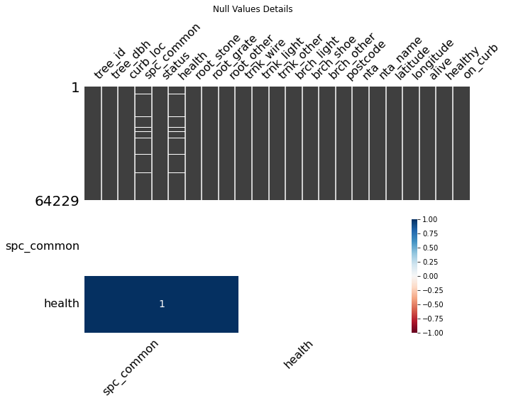

```python
#import missingno package
import missingno as msno

#create figure
fig, (ax1, ax2) = plt.subplots(2, 1, figsize = (10,8), tight_layout = True)
fig.suptitle('Null Values Details')

#create ax1 to find out if missing values are determined by tree_dbh
ax1 = msno.matrix(trees.sort_values('tree_dbh'), ax = ax1)

#create ax2 to find out if missing values are correlated
ax2 = msno.heatmap(trees, ax = ax2)

#show figure
plt.show()
```

```python
#print out percentage of missing values
print('Percentage of missing values: ', round(100*(max(trees.isna().sum()) / trees.shape[0]),2), '%')
```

```
Percentage of missing values:  2.81 %
```

```python
#check for dead trees
trees.query('status != "Alive"').isna().sum()
```

```
tree_id          0
tree_dbh         0
curb_loc         0
spc_common    1801
status           0
health        1802
root_stone       0
root_grate       0
root_other       0
trnk_wire        0
trnk_light       0
trnk_other       0
brch_light       0
brch_shoe        0
brch_other       0
postcode         0
nta              0
nta_name         0
latitude         0
longitude        0
alive            0
healthy          0
on_curb          0
dtype: int64
```

We can see that the null values came from dead trees. Let's make necessary changes to reflect the dead trees.

```python
#replace null values on health with dead and turn it into ordinal data
trees['health'] = trees.health.fillna('Dead')
#initialize mapping
health_map = {'Dead' : 0, 'Poor' : 1, 'Fair' : 2, 'Good' : 3}
#map into ordinal data
trees['health'].replace(health_map, inplace = True)

#replace null values on species with unidentified
trees['spc_common'] = trees.spc_common.fillna('Unidentified')
```

## Check for duplicates

```python
#We will change the spc_common values to have proper nouns
species_capitalize = []
for entry in list(trees.spc_common.str.split()):
    new_entry = []
    for word in entry:
        new_entry.append(word.capitalize())
    to_enter = ' '.join(new_entry)
    to_enter = to_enter.strip()
    species_capitalize.append(to_enter)
trees['spc_common'] = species_capitalize

#check dataframe
trees.head()
```

|  | tree_id | tree_dbh | curb_loc | spc_common | status | health | root_stone | root_grate | root_other | trnk_wire | ... | brch_shoe | brch_other | postcode | nta | nta_name | latitude | longitude | alive | healthy | on_curb |
| --- | --- | --- | --- | --- | --- | --- | --- | --- | --- | --- | --- | --- | --- | --- | --- | --- | --- | --- | --- | --- | --- |
| 0 | 190422 | 11 | OnCurb | Honeylocust | Alive | 3 | False | False | False | False | ... | False | False | 10023 | MN14 | Lincoln Square | 40.770046 | -73.984950 | True | True | True |
| 1 | 190426 | 11 | OnCurb | Honeylocust | Alive | 3 | False | False | False | False | ... | False | False | 10023 | MN14 | Lincoln Square | 40.770210 | -73.985338 | True | True | True |
| 2 | 208649 | 9 | OnCurb | American Linden | Alive | 3 | False | True | False | False | ... | False | False | 10019 | MN15 | Clinton | 40.762724 | -73.987297 | True | True | True |
| 3 | 193310 | 14 | OnCurb | Honeylocust | Alive | 3 | False | False | True | False | ... | False | True | 10021 | MN40 | Upper East Side-Carnegie Hill | 40.772171 | -73.960456 | True | True | True |
| 4 | 199760 | 4 | OnCurb | Willow Oak | Alive | 2 | False | False | False | False | ... | False | False | 10024 | MN12 | Upper West Side | 40.782087 | -73.980964 | True | False | True |

5 rows × 23 columns

```python
#check for duplicated rows
trees.duplicated().sum()
```

```
0
```

There are no duplicated rows. We are now confident that we have thoroughly cleaned our data. We are free to begin analysis.

# Analysis

## What are the most common tree species in Manhattan?

We made an assumption from the nta codes that all the trees in the dataset are located at Manhattan, we will make sure of that.

```python
#merge trees data with neighborhoods geodata
trees_neighborhoods = trees.merge(neighborhoods[['boroname', 'ntacode']], left_on = 'nta', right_on = 'ntacode', how = 'left')

#print out unique entries on boroname column
trees_neighborhoods.boroname.unique()
```

```
array(['Manhattan'], dtype=object)
```

Now that we are sure, let us proceed in finding the most common species

```python
#group trees by species, aggregate by count
trees_grouped_by_species = trees.query('status == "Alive"').groupby('spc_common').agg({'spc_common': 'count'})\
														.rename(columns = {'spc_common' : 'count'})\
														.reset_index()\
														.sort_values('count', ascending = False)
```

```python
#create visual style
wood_color = '#340006'
sns.set_style('darkgrid', {'grid.color' : wood_color,
                           'axes.facecolor' : 'gray',
                           'figure.facecolor' : 'lightgray'})
```

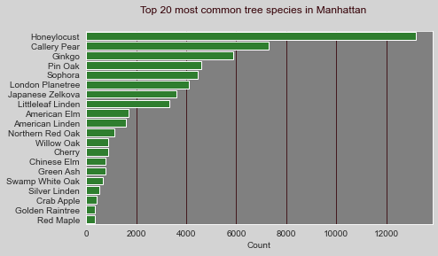

```python
#initialize figure
fig = plt.figure (figsize = (7,4))
#set figure title
fig.suptitle('Top 20 most common tree species in Manhattan', color = wood_color)

#create barplot
ax = sns.barplot(data = trees_grouped_by_species.nlargest(20, 'count'), y = 'spc_common', x = 'count', color = 'forestgreen')
ax.set_ylabel('')
ax.set_xlabel('Count')

#show plot
plt.show()
```

**Observations**

## Which are the neighborhoods with the most trees?

### Create aggregated table with details about each Manhattan neighborhood

```python
#create table grouped by neighborhood
trees_grouped_by_neighborhood = trees.groupby('nta').agg({'nta_name': 'count',
                                                               'tree_dbh' : 'mean',
                                                               'health' : 'mean',
                                                               'alive' : 'mean',
                                                              'on_curb' : 'mean',
                                                               'root_stone' :'mean',
                                                               'root_grate' : 'mean',
                                                               'root_other' : 'mean',
                                                               'trnk_wire' : 'mean',
                                                               'trnk_light' : 'mean',
                                                               'trnk_other' : 'mean',
                                                               'brch_light' : 'mean',
                                                               'brch_shoe' : 'mean',
                                                               'brch_other' : 'mean',
                                                              })\
                                                        .reset_index().rename(columns = {'nta_name' : 'trees_count', 'health' : 'average_health'})

#create table with neighborhood names and nta codes
nta_and_name = pd.DataFrame(trees.groupby('nta')['nta_name'].apply(lambda name: max(name)))

#join table with neighbborhood names
trees_grouped_by_neighborhood = nta_and_name.merge(trees_grouped_by_neighborhood, on = 'nta')
```

```python
#subset neighborhoods table with only Manhattan nbhd entries
Manhattan_neighborhoods = neighborhoods[neighborhoods.ntacode.str.contains('MN')]
#create nbhd centers
Manhattan_neighborhoods['center_lng'] = Manhattan_neighborhoods.geometry.centroid.x
Manhattan_neighborhoods['center_lat'] = Manhattan_neighborhoods.geometry.centroid.y

#join with trees aggregated table, we now have a table with all information about each neighborhood and its aggregated tree data
Manhattan_neighborhoods_and_trees = Manhattan_neighborhoods.merge(trees_grouped_by_neighborhood,
                                                                  left_on = 'ntacode', right_on = 'nta', how = 'right')\
                                                            .drop(['nta', 'nta_name'], axis = 1)
```

```python
#conversion from square meters to square kilometers
sqm_to_sqkm = 10**6

#create a copy of our main table, change epsg to have meter units
dense_find = Manhattan_neighborhoods_and_trees.copy()
dense_find['geometry'] = Manhattan_neighborhoods_and_trees.geometry.to_crs(epsg = 3857)
#transform shape area to have square kilometer units
dense_find['shape_area'] = dense_find.geometry.area / sqm_to_sqkm
#find density
dense_find['tree_density'] = dense_find['trees_count'] / dense_find['shape_area']

#add tree_density column to dataframe
Manhattan_neighborhoods_and_trees['tree_density'] = dense_find['tree_density']
#change area column values to square kilometer units
Manhattan_neighborhoods_and_trees['area'] = dense_find['shape_area']
#drop shape_area column
Manhattan_neighborhoods_and_trees.drop('shape_area', axis = 1, inplace = True)

#delete frame used to find density and area values
del dense_find
```

### Plot neighborhoods tree counts

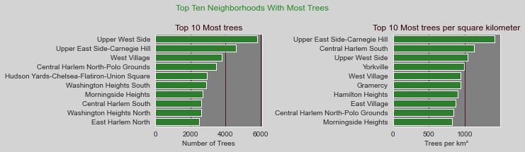

```python
#ninitialize figure with one row and two columns
fig, ax = plt.subplots (1,2, figsize = (10,3), tight_layout = True)
fig.suptitle('Top Ten Neighborhoods With Most Trees', color = 'forestgreen')

#create barplot with neighborhoods with most trees
ax1 = sns.barplot(data = Manhattan_neighborhoods_and_trees.nlargest(10, 'trees_count'),
                  y = 'ntaname', x = 'trees_count',
                  color = 'forestgreen', ax = ax[0])
ax1.set_title('Top 10 Most trees', color = wood_color)
ax1.set_ylabel('')
ax1.set_xlabel('Number of Trees')

#create barplot with most dense neighborhoods
ax2 = sns.barplot(data = Manhattan_neighborhoods_and_trees.nlargest(10, 'tree_density'),
                  y = 'ntaname', x = 'tree_density',
                  color = 'forestgreen', ax = ax[1])
ax2.set_title('Top 10 Most trees per square kilometer', color = wood_color)
ax2.set_ylabel('')
ax2.set_xlabel('Trees per km\u00B2')

plt.show()
```

```python
#check for intersection between the two charts above

#change the lists to sets
top_ten_most_dense_nbhd = set(Manhattan_neighborhoods_and_trees.nlargest(10, 'tree_density').ntaname)
top_ten_most_trees_nbhd = set(Manhattan_neighborhoods_and_trees.nlargest(10, 'trees_count').ntaname)

#find intersection
intersection = list(top_ten_most_dense_nbhd.intersection(top_ten_most_trees_nbhd))

#print intersection
print("The Neighborhoods appears on both lists are: " , ', '.join(intersection))
```

```
The Neighborhoods appears on both lists are:  Morningside Heights, Upper East Side-Carnegie Hill, Upper West Side, Central Harlem North-Polo Grounds, Central Harlem South, West Village
```

We will further investigate the neighborhoods of Manhattan and their trees, for now we can say that the most of the neighborhoods with the most trees tend to be the most densed with trees.

## A visualization of Manhattan's neighborhoods and tree locations.

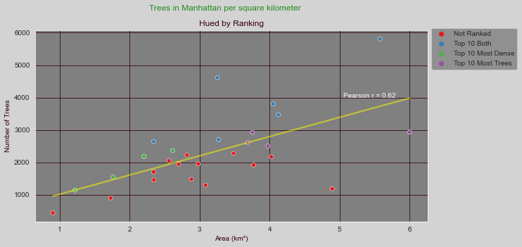

```python
#import pearson r score
from scipy.stats import pearsonr

#create new column to show if neighborhood is ranked with most number of trees or most dense with trees
#initialize empty list
nbhd_classification = []
#loop through neighborhoods
for nbhd in Manhattan_neighborhoods_and_trees['ntaname']:
    if nbhd in intersection:
        nbhd_classification.append('Top 10 Both')
    elif nbhd in top_ten_most_trees_nbhd:
        nbhd_classification.append('Top 10 Most Trees')
    elif nbhd in top_ten_most_dense_nbhd:
        nbhd_classification.append('Top 10 Most Dense')
    else:
        nbhd_classification.append('Not Ranked')

#insert new column
Manhattan_neighborhoods_and_trees['nbhd_tree_count_classification'] = nbhd_classification

#find Pearson r correlation score
r_score = pearsonr(Manhattan_neighborhoods_and_trees.area, Manhattan_neighborhoods_and_trees.trees_count)
leg_kwds={
'loc': 'upper left',
'bbox_to_anchor':(1, 1.03)}

#initialize figure
fig, ax = plt.subplots(1,1, figsize = (10,5))
fig.suptitle('Trees in Manhattan per square kilometer', color = 'forestgreen')

#create scatterplot
ax = sns.scatterplot(data = Manhattan_neighborhoods_and_trees,x = 'area', y = 'trees_count',
                hue = 'nbhd_tree_count_classification', palette = 'Set1',
                legend = True)

#create regplot, hide scatter points to show plot above, set ci = None to show only best fit line
ax = sns.regplot(data = Manhattan_neighborhoods_and_trees,x = 'area', y = 'trees_count',
                 scatter_kws = {'alpha' : 0}, line_kws = {'color' : 'yellow', 'alpha' : 0.5}, ci = None)

#set title and labels
ax.set_title('Hued by Ranking', color = wood_color)
ax.set_xlabel('Area (km\u00B2)', color = wood_color)
ax.set_ylabel('Number of Trees', color = wood_color)
ax.text(5.05, 4000, f'Pearson r = {r_score[0].round(2)}', color = 'white')

#position legend outside plot
ax.legend(bbox_to_anchor = (-0.7,1),loc = 'upper left')

plt.legend(bbox_to_anchor = (1, 1.03), loc = 'upper left')
plt.show()
```

**Pearson r score**

- It is a number that indicates correlation between two variables.
- It ranges from -1 to +1.
- A number close to -1 indicates stronger negative correlation. Where one variable increases while the other decreases.
- A number close to 0 indicates weak or no corration if 0.
- A number close to +1 indicates stronger positive correlation. Where both variables increase or decrease together.

**Observations**

- We could see that there is a medium positive correlation between the neighborhoods area and the number of trees in it. Correlation is strongest and most positive on the most dense neighborhoods, but that is not a surprise.
- Most neighborhoods has under 3000 trees, including some large neighborhoods. We will look at whether the amount of harm done on the trees lessen those numbers.

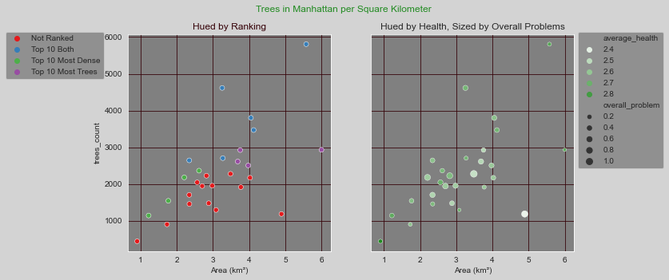

```python
#add up the values of the problem on trees
harm_rating = Manhattan_neighborhoods_and_trees[to_bool]
Manhattan_neighborhoods_and_trees['overall_problem'] = harm_rating.sum(axis = 1)

#initialize green palette
green_pal = sns.light_palette('green', as_cmap = True)

#initialize figure with 1 row and 2 columns
fig, ax = plt.subplots(1,2, figsize = (10,5), sharey = True)
fig.suptitle('Trees in Manhattan per Square Kilometer', color = 'forestgreen')

#create 1st plot
ax1 = sns.scatterplot(data = Manhattan_neighborhoods_and_trees,x = 'area', y = 'trees_count',
                hue = 'nbhd_tree_count_classification', palette = 'Set1',
                legend = True, ax = ax[0])
ax1.legend(bbox_to_anchor = (-0.75,1),loc = 'upper left')
ax1.set_title('Hued by Ranking', color = wood_color)
ax1.set_xlabel('Area (km\u00B2)')
ax1.legend(bbox_to_anchor = (-0.1, 1.03), loc = 'upper right')

#create temporary dataframe with average tree problems for each neighborhood
harm_rating = Manhattan_neighborhoods_and_trees[to_bool]
#add values for each row, we now have average overall problem for each tree for each neighborhood
Manhattan_neighborhoods_and_trees['overall_problem'] = harm_rating.sum(axis = 1)

#initialize light green palette
green_pal = sns.light_palette('forestgreen', as_cmap = True)

#create second plot
ax2 = sns.scatterplot(data = Manhattan_neighborhoods_and_trees, x = 'area', y = 'trees_count',
                hue = 'average_health', palette = green_pal,
                size = 'overall_problem', ax = ax[1])
ax2.set_title('Hued by Health, Sized by Overall Problems')
ax2.set_xlabel('Area (km\u00B2)')
ax2.legend(bbox_to_anchor = (1,1.03))

#show plots
plt.show()
```

**Observation**

- The neighborhoods that was not ranked tend to have more overall problems with their trees.
- This could mean that the neighborhoods who do not provide good care for the trees tend to have less trees.
- The fainter dots tend to be the bigger ones, this means that care on the trees tend to have an effect on its health.

```python
#import folium
import folium

#find center of Manhattan, we need this to center our map
centerpoint = [np.median(trees.latitude) + .01, np.median(trees.longitude)- .01]

#initialize folium map
Manhattan = folium.Map(location = centerpoint,
                       zoom_start = 11.5,
                       width = 700, height = 800,
                       zoom_control=False,
                       scrollWheelZoom=False,
                       dragging=False,
                      legend = 'Manhattan',
                      tiles = 'cartodbpositron')

#create base map for initial view of map
base_map = folium.FeatureGroup(name = 'base', overlay = False, control = False).add_to(Manhattan)
folium.TileLayer(tiles = 'cartodbpositron').add_to(base_map)
base_map.add_to(Manhattan)

#create popups that show neighborhood name, and number of trees
for lab, row in Manhattan_neighborhoods_and_trees.iterrows():
    location = [row.center_lat, row.center_lng]
    popup = row.ntaname + ', trees: ' + str(row.trees_count)
    folium.Marker(location = location, popup = popup).add_to(base_map)


#create choropleth layer based on Trees per Square kilometer
layer1 = folium.Choropleth(geo_data = Manhattan_neighborhoods_and_trees,
                     name = 'Trees per Square Kilometer',
                     data = Manhattan_neighborhoods_and_trees,
                     columns = ['ntaname', 'tree_density'],
                    key_on = 'feature.properties.ntaname',
                    fill_color = 'BuGn', fill_opacity = 20,
                    legend_name = 'Trees per square kilometer by neighborhood', overlay = False).add_to(Manhattan)

#create choropleth layer based on number of trees
layer2 = folium.Choropleth(geo_data = Manhattan_neighborhoods_and_trees,
                     name = 'Tree Count',
                     data = Manhattan_neighborhoods_and_trees,
                     columns = ['ntaname', 'trees_count'],
                    key_on = 'feature.properties.ntaname',
                    fill_color = 'BuGn', fill_opacity = 20,
                    legend_name = 'Trees by neighborhood', overlay = False).add_to(Manhattan)

#create choropleth layer based on average tree diameter
layer3 =  Manhattan.choropleth(geo_data = Manhattan_neighborhoods_and_trees,
                     name = 'Average Tree Diameter',
                     data = Manhattan_neighborhoods_and_trees,
                     columns = ['ntaname', 'tree_dbh'],
                    key_on = 'feature.properties.ntaname',
                    fill_color = 'BuGn', fill_opacity = 20,
                    legend_name = 'Average Tree Diameter', overlay = False)

#create choropleth layer based on tree health
layer4 =  Manhattan.choropleth(geo_data = Manhattan_neighborhoods_and_trees,
                     name = 'Average Tree Health',
                     data = Manhattan_neighborhoods_and_trees,
                     columns = ['ntaname', 'average_health'],
                    key_on = 'feature.properties.ntaname',
                    fill_color = 'BuGn', fill_opacity = 20,
                    legend_name = 'Average Tree Health', overlay = False)

#create choropleth layer based on average tree problems
harm_layer =  folium.Choropleth(geo_data = Manhattan_neighborhoods_and_trees,
                     name = 'Average Problem per Tree',
                     data = Manhattan_neighborhoods_and_trees,
                     columns = ['ntaname', 'overall_problem'],
                    key_on = 'feature.properties.ntaname',
                    fill_color = 'PuRd', fill_opacity = 20,
                    legend_name = 'Average Problem per Tree', overlay = False, legend = False).add_to(Manhattan)

#create choropleth layer based on percentege of trees planted on curb
curb_layer =  folium.Choropleth(geo_data = Manhattan_neighborhoods_and_trees,
                     name = 'Average on curb rate',
                     data = Manhattan_neighborhoods_and_trees,
                     columns = ['ntaname', 'on_curb'],
                    key_on = 'feature.properties.ntaname',
                    fill_color = 'Greys', fill_opacity = 20,
                    legend_name = 'Average on curb rate', overlay = False, legend = False).add_to(Manhattan)

#add in layer control for view control
folium.LayerControl(collapsed = False, position = 'topright').add_to(Manhattan)

#display folium map
Manhattan
```

Make this Notebook Trusted to load map: File -> Trust Notebook

[interactive chart not shown]

**On using the map**

- If map does not show, please open on Jupyter Notebook.
- Clicking on each layer shows a choropleth that colors the map by the specific feature.
- The rectangular area in the middle is Central Park.

**Observations**

- The neighborhoods with the highest average tree health does not necessarily has the trees with the biggest diameter. This could be because of the species of trees in each area.
- The shades on the layers about tree health, diameter, and abundance are similar, while it reverses when we look at the average problem per tree.
- A vast majority of the neighborhoods tend to plant most of their trees on curb.

## What ten tree species would you recommend the city plant in the future?

**What to find?**

- From the analysis above, the neighborhoods that are dense with trees have apply less harm to their trees. If the city will plant a tree, it would most likely be on the neighborhoods with less amount of trees. Hence, we need to find a species that can withstand the harm done with it.

### Which species are most common on neighborhoods most densed with trees?

```python
#group trees by neighborhood, then species, filter to neighborhoods in most dense ranking
trees_grouped_by_nbhd = trees[trees.nta_name.isin(top_ten_most_dense_nbhd)].groupby(['nta_name', 'spc_common'])\
                                .agg({'spc_common' : 'count'})\
                                .rename(columns = {'spc_common' : 'count'}).sort_values('count', ascending = False)

#find the top 5 most prevalent trees in each neighborhood
trees_grouped_by_nbhd_most_common_species = trees_grouped_by_nbhd.groupby(level = 'nta_name').head(5).sort_values(['nta_name', 'count'], ascending = [True, False])

#get species names, input to list
most_common_trees_in_most_densed_nbhd = list(trees_grouped_by_nbhd_most_common_species.reset_index().spc_common.unique())

#show dataframe
trees_grouped_by_nbhd_most_common_species
```

| nta_name | spc_common | count |
| --- | --- | --- |
| Central Harlem North-Polo Grounds | Honeylocust | 640 |
|  | Callery Pear | 451 |
|  | Pin Oak | 273 |
|  | Sophora | 269 |
|  | London Planetree | 265 |
| Central Harlem South | Honeylocust | 441 |
|  | Ginkgo | 280 |
|  | London Planetree | 252 |
|  | Callery Pear | 234 |
|  | Japanese Zelkova | 196 |
| East Village | Honeylocust | 322 |
|  | Callery Pear | 197 |
|  | Sophora | 150 |
|  | Ginkgo | 143 |
|  | Littleleaf Linden | 101 |
| Gramercy | Honeylocust | 231 |
|  | Ginkgo | 185 |
|  | Callery Pear | 166 |
|  | Sophora | 94 |
|  | London Planetree | 91 |
| Hamilton Heights | Pin Oak | 426 |
|  | Honeylocust | 385 |
|  | Sophora | 166 |
|  | London Planetree | 140 |
|  | Callery Pear | 127 |
| Morningside Heights | Honeylocust | 391 |
|  | Ginkgo | 371 |
|  | American Elm | 296 |
|  | Callery Pear | 232 |
|  | Pin Oak | 225 |
| Upper East Side-Carnegie Hill | Callery Pear | 828 |
|  | Honeylocust | 725 |
|  | Ginkgo | 569 |
|  | American Elm | 390 |
|  | Littleleaf Linden | 286 |
| Upper West Side | Honeylocust | 972 |
|  | Pin Oak | 809 |
|  | Ginkgo | 533 |
|  | Sophora | 492 |
|  | Callery Pear | 462 |
| West Village | Callery Pear | 568 |
|  | Honeylocust | 560 |
|  | Ginkgo | 535 |
|  | Sophora | 280 |
|  | London Planetree | 246 |
| Yorkville | Honeylocust | 680 |
|  | Callery Pear | 286 |
|  | Ginkgo | 188 |
|  | Littleleaf Linden | 147 |
|  | Sophora | 129 |

### Recommended Trees

```python
#create overall_harm for each tree
trees['overall_harm'] = trees[to_bool].sum(axis = 1)

#create dataframe of trees grouped by species
trees_by_species = trees.groupby('spc_common').agg({'tree_dbh' : 'mean',
                                                    'spc_common' : 'count',
                                                    'tree_dbh' : 'mean',
                                                    'health' : 'mean',
                                                    'overall_harm' : 'mean',
                                                    'on_curb' : 'mean'})

#rename spc_common to species
trees_by_species.index.rename('species', inplace = True)
#rename spc_common columns that contatins the count of the species with count
trees_by_species.rename(columns = {'spc_common' : 'count'}, inplace = True)
```

[figure not shown]

```python
#create red_pal
red_pal = sns.light_palette('red', as_cmap = True)

#We will pick trees that have count more than 15 to ensure that the trees recommended are not rare
sns.scatterplot(data = trees_by_species.query('count > 15'), x = 'tree_dbh' , y = 'health',
                hue = 'overall_harm', palette = red_pal)
plt.title('Species with count more than 20', color = 'forestgreen')
plt.show()
```

**Observations**

- Notice that the average health of most species in this set is higher than 2.0, this means that most trees under these species are in better than fair health.

**Strategy**

- We want to look for trees that can stay healthy while exposed to more problems. We also want trees that are proven to be survive being planted on curb.
- We will filter out by using overall_harm to have species that can withstand harm.Then as decision maker we will use the trees with the largest diameters

```python
#import termcolor, so we can color the trees we recommend
from termcolor import colored

#filter trees_by_species to show trees that have the specs that we need, get 10 largest in terms of trunk diameter.
trees_to_plant = trees_by_species.query('(count > 15) and (health > 2.5) and (tree_dbh > 7) and (overall_harm > 0.4) and (on_curb > 0.5)').nlargest(10, 'tree_dbh')

#show recommendations
print(colored("The trees we recommend that the city should plant are:",'green'))
print(colored(', '.join(list(trees_to_plant.index)), 'green'))
```

```
The trees we recommend that the city should plant are:
American Elm, London Planetree, Siberian Elm, Ohio Buckeye, Tree Of Heaven, Mulberry, Willow Oak, Pin Oak, Black Locust, Black Walnut
```

```python
#show recommendations with their features
trees_to_plant = trees_to_plant.round(2)
trees_to_plant['label'] = 'recommended'
trees_to_plant
```

| species | tree_dbh | count | health | overall_harm | on_curb | label |
| --- | --- | --- | --- | --- | --- | --- |
| American Elm | 13.90 | 1698 | 2.76 | 0.43 | 0.72 | recommended |
| London Planetree | 13.17 | 4122 | 2.54 | 0.48 | 0.83 | recommended |
| Siberian Elm | 12.06 | 156 | 2.79 | 0.42 | 0.92 | recommended |
| Ohio Buckeye | 11.96 | 24 | 2.71 | 0.88 | 0.96 | recommended |
| Tree Of Heaven | 11.45 | 104 | 2.74 | 0.78 | 0.96 | recommended |
| Mulberry | 11.00 | 68 | 2.63 | 0.46 | 0.88 | recommended |
| Willow Oak | 10.81 | 889 | 2.81 | 0.59 | 0.97 | recommended |
| Pin Oak | 10.07 | 4584 | 2.78 | 0.47 | 0.91 | recommended |
| Black Locust | 9.77 | 259 | 2.75 | 0.54 | 0.98 | recommended |
| Black Walnut | 9.64 | 33 | 2.76 | 0.58 | 1.00 | recommended |

```python
#most common trees on nbhds that are most densed with trees
trees_0 = trees_by_species[trees_by_species.index.isin(most_common_trees_in_most_densed_nbhd)].round(2)
trees_0['label'] = 'on most dense'

#show most prevalent trees with their features
trees_0
```

| species | tree_dbh | count | health | overall_harm | on_curb | label |
| --- | --- | --- | --- | --- | --- | --- |
| American Elm | 13.90 | 1698 | 2.76 | 0.43 | 0.72 | on most dense |
| Callery Pear | 8.68 | 7297 | 2.68 | 0.64 | 0.97 | on most dense |
| Ginkgo | 8.45 | 5859 | 2.66 | 0.56 | 0.96 | on most dense |
| Honeylocust | 9.06 | 13176 | 2.82 | 0.70 | 0.95 | on most dense |
| Japanese Zelkova | 7.04 | 3596 | 2.71 | 0.51 | 0.95 | on most dense |
| Littleleaf Linden | 7.87 | 3333 | 2.48 | 0.55 | 0.94 | on most dense |
| London Planetree | 13.17 | 4122 | 2.54 | 0.48 | 0.83 | on most dense |
| Pin Oak | 10.07 | 4584 | 2.78 | 0.47 | 0.91 | on most dense |
| Sophora | 9.23 | 4453 | 2.76 | 0.57 | 0.96 | on most dense |

```python
#show trees that appeared on both recommendation and most prevalent on most dense nbhds
print(f'The trees that we recommended that are most prevalent on the neighborhoods with most trees are ', ', '.join(list(set(trees_to_plant.index).intersection(set(trees_0.index)))))
```

```
The trees that we recommended that are most prevalent on the neighborhoods with most trees are  London Planetree, American Elm, Pin Oak
```

### Comparing recommended trees to trees most prevalent in most densed neighborhoods

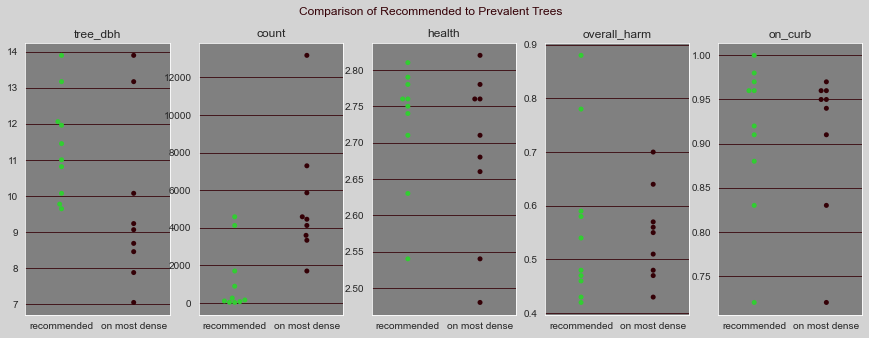

```python
#concatened both tables, this is to make swarmplots
joined = pd.concat([trees_to_plant, trees_0])

#initiate figure
fig, ax = plt.subplots(1, 5, figsize = (15,5))

#set title
fig.suptitle('Comparison of Recommended to Prevalent Trees', color = wood_color)

#loop through columns to make swarmplots
for i, col in enumerate(['tree_dbh', 'count', 'health', 'overall_harm', 'on_curb']):
    ax[i] = sns.swarmplot(data = joined, y = col, x = 'label', ax = ax[i], palette = ['limegreen', wood_color])
    ax[i].set_title(col)
    ax[i].set_xlabel('')
    ax[i].set_ylabel('')

#show plot
plt.show()
```

**Observations**

```python
print(colored("The trees we recommend that the city should plant are:",'green'))
print(colored(', '.join(list(trees_to_plant.index)), 'green'))
```

```
The trees we recommend that the city should plant are:
American Elm, London Planetree, Siberian Elm, Ohio Buckeye, Tree Of Heaven, Mulberry, Willow Oak, Pin Oak, Black Locust, Black Walnut
```